# L'inflation insoutenable en Espagne?

### Alexandre Lohman **

La semaine dernière, nous avons évoqué le scénario économique en Allemagne, démontrant que l’inflation au producteur industriel dans ce pays pourrait atteindre un plus haut depuis 40 ans à la fin de l’année. Cette semaine, nous aborderons la situation encore plus préoccupante de l’Espagne qui affiche un taux d’inflation PPI (Indice des prix au Producteur ou IPP en français) de 15.3% en variation annuelle. **Ce taux correspond à plus du double de celui l’Allemagne (7.2%) et est le plus élevé enregistré dans le pays depuis 1983** (Graphique 1).

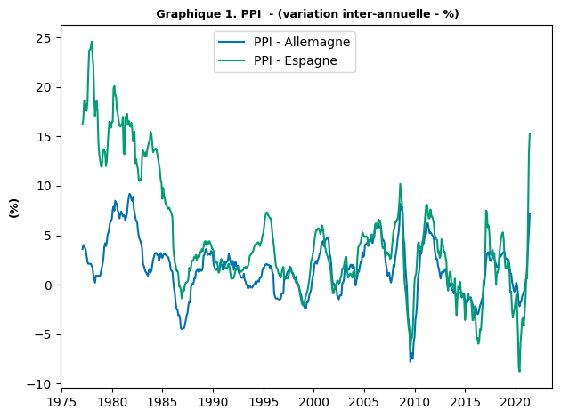

**Une partie importante du différentiel d’inflation entre les deux pays s’explique par un effet de base**, le choc déflationniste de 2020 ayant été beaucoup plus profond en Espagne. Néanmoins, une autre partie de ce surplus s’explique par un processus inflationniste plus dynamique. En effet, en Mai 2021, les prix industriels espagnols étaient 6.49% au-dessus de leur niveau de janvier 2020 contre seulement 4.76% en Allemagne. (Graphique 2).

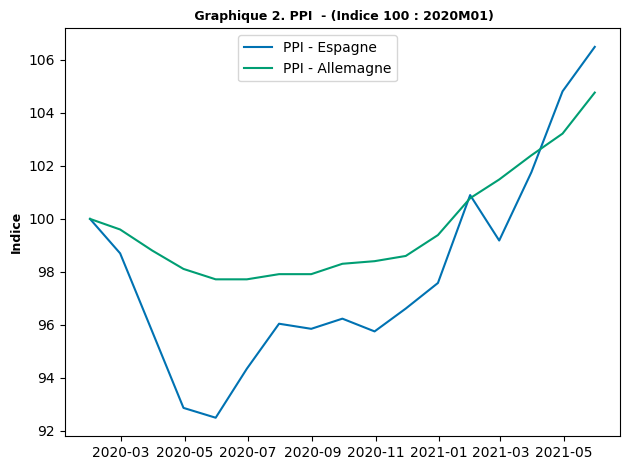

De plus, la force de l’inflation des produits industriels espagnols ces derniers mois interpelle : les prix ont accumulés une hausse de 9.13% depuis Janvier 2021 contre seulement 5.41% en Allemagne sur la même période. Ceci est dû à une plus forte hausse des prix de l’énergie (+17.91% en Espagne contre +8.39% en Allemagne) mais également à une plus grande dissémination de la hausse dans la catégorie des biens de consommation (+3.34% en Espagne contre +1.69% en Allemagne pour les biens de consommation non durable).

**Si la situation perdure, elle pourrait être problématique car l’Espagne partage la même monnaie que l’Allemagne et elle ne dispose donc pas de la capacité de déprécier son taux de change pour compenser les pertes de compétitivité.**

Il est bon de noter que, bien souvent, les analyses en termes de compétitivité prix sont faites en considérant les indices de prix au consommateur (IPC). A mon avis, ce type d’analyse n’est pas judicieux. En effet, l’indice des prix au consommateur est surtout composé de services payés directement par les ménages alors que les exportations concernent avant tout des produits manufacturés et sont payés d’entreprise importatrice à entreprise exportatrice. L’indice des prix au consommateur est donc un mauvais indicateur de la compétitivité-prix d’une économie.

Naturellement, le souvenir de la crise de l’euro aidant, notre regard se porte sur les statistiques des autres pays du Sud de l’Europe (Portugal, Italie et Grèce). J’ai décidé de reproduire le calcul fait précédemment pour comparer les prix actuels à leur niveau de janvier 2020 afin d’éliminer l’impact statistique trompeur de la première vague de Covid-19 (Graphique 3. NB : les données du mois de Mai ne sont pas encore disponibles pour la Grèce et l’Italie.)

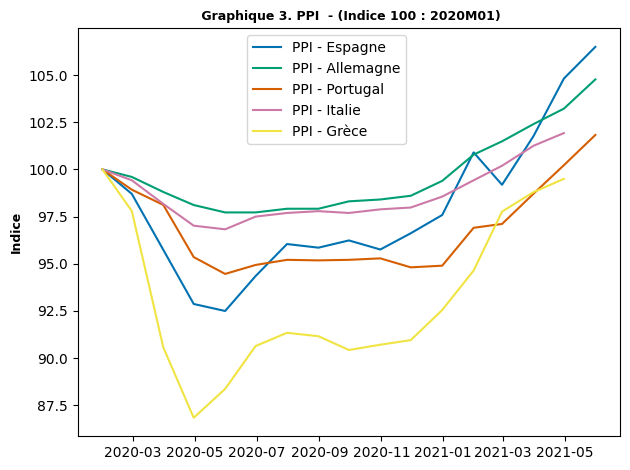

**Conclusion:** Du côté de l’inflation, la situation espagnole est moins grave que ne le laissent suggérer le taux en variation interannuel très élevé. Néanmoins, la dynamique du processus inflationniste est très forte et mérite d’être accompagnée de près alors que l’Espagne pourrait déjà avoir une monnaie surévalué. De plus un éventuel pic d’inflation une année particulière, même s’il est la contrepartie d’une déflation prononcée l’année précédente, n’est pas neutre car il transmet sur l’année suivante une persistance inflationniste plus grande via l’indexation des salaires.

[figure not shown]

##### Cette newsletter est publiée gratuitement mais il est possible de nous soutenir en nous laissant quelques pourboires (2€...) en cliquant sur ce lien sécurisé. **Votre soutien est important pour nous permettre d’inscrire ce projet dans le temps long.**

** Economiste basé au Brésil, Maître en Economie (Université de Coimbra, Portugal) - top 3 des économistes prévisionnistes, inflation générale de marché dans les catégories moyen et long terme au Brésil.